# Cleaning the Data

```python
clean_df = clean_columns(df)
#clean_df.columns.tolist()
```

```
52 column names have been cleaned
```

```python
clean_df2 = clean_columns(df2)
clean_df2.columns.tolist()
```

```
4 column names have been cleaned
```

```
['lake_name',
 'surface_area_acres',
 'watershed_acres',
 'average_depth_ft',
 'maximum_depth_ft']
```

```python
merge_df = pd.merge(clean_df, clean_df2, on="lake_name")
merge_df.head()
```

|  | lake_name | site_type | id_# | date | time | pw | w | total_depth_m | secchi_depth | depth_m | ... | weather_meter_# | fluorometer_# | aquafluor_# | van_dorn_# | unnamed_50 | unnamed_51 | surface_area_acres | watershed_acres | average_depth_ft | maximum_depth_ft |
| --- | --- | --- | --- | --- | --- | --- | --- | --- | --- | --- | --- | --- | --- | --- | --- | --- | --- | --- | --- | --- | --- |
| 0 | Beaver Dam | Open | 21221BEA2 | 8/9/2021 | 15:40 | S | S | 18.5 | 2.5 | 0.0 | ... | NaN | NaN | NaN | NaN | NaN | NaN | 155 | 1266 | 15.6 | 61 |
| 1 | Beaver Dam | Open | 18190BEA2 | 7/9/2018 | 15:00 | S | S | 18.0 | 3.0 | 0.0 | ... | NaN | NaN | NaN | NaN | NaN | NaN | 155 | 1266 | 15.6 | 61 |
| 2 | Beaver Dam | Open | 18204BEA2 | 7/23/2018 | 15:15 | R | R | 19.0 | 5.8 | 0.0 | ... | NaN | NaN | NaN | NaN | NaN | NaN | 155 | 1266 | 15.6 | 61 |
| 3 | Beaver Dam | Open | 18211BEA2 | 7/31/2018 | 15:00 | O | O | 18.6 | 4.4 | 0.0 | ... | NaN | NaN | NaN | NaN | NaN | NaN | 155 | 1266 | 15.6 | 61 |
| 4 | Beaver Dam | Open | 18218BEA2 | 8/6/2018 | 14:45 | S | O | 18.8 | 4.4 | 0.0 | ... | NaN | NaN | NaN | NaN | NaN | NaN | 155 | 1266 | 15.6 | 61 |

5 rows × 56 columns

```python
m_df = merge_df.drop(['site_type','mc_id', 'ac_id', 'pw', 'w', 'epi_hypo', 'notes'], axis = 1).dropna(how = "all")
m_df.head()
```

|  | lake_name | id_# | date | time | total_depth_m | secchi_depth | depth_m | water_temp_cel_s | do_%_sat | do_mg_l | ... | weather_meter_# | fluorometer_# | aquafluor_# | van_dorn_# | unnamed_50 | unnamed_51 | surface_area_acres | watershed_acres | average_depth_ft | maximum_depth_ft |
| --- | --- | --- | --- | --- | --- | --- | --- | --- | --- | --- | --- | --- | --- | --- | --- | --- | --- | --- | --- | --- | --- |
| 0 | Beaver Dam | 21221BEA2 | 8/9/2021 | 15:40 | 18.5 | 2.5 | 0.0 | 26.90 | 113.4 | 9.05 | ... | NaN | NaN | NaN | NaN | NaN | NaN | 155 | 1266 | 15.6 | 61 |
| 1 | Beaver Dam | 18190BEA2 | 7/9/2018 | 15:00 | 18.0 | 3.0 | 0.0 | 28.83 | 115.0 | 8.75 | ... | NaN | NaN | NaN | NaN | NaN | NaN | 155 | 1266 | 15.6 | 61 |
| 2 | Beaver Dam | 18204BEA2 | 7/23/2018 | 15:15 | 19.0 | 5.8 | 0.0 | 25.21 | 88.7 | 7.27 | ... | NaN | NaN | NaN | NaN | NaN | NaN | 155 | 1266 | 15.6 | 61 |
| 3 | Beaver Dam | 18211BEA2 | 7/31/2018 | 15:00 | 18.6 | 4.4 | 0.0 | 25.10 | 103.3 | 8.55 | ... | NaN | NaN | NaN | NaN | NaN | NaN | 155 | 1266 | 15.6 | 61 |
| 4 | Beaver Dam | 18218BEA2 | 8/6/2018 | 14:45 | 18.8 | 4.4 | 0.0 | 28.77 | 120.2 | 9.30 | ... | NaN | NaN | NaN | NaN | NaN | NaN | 155 | 1266 | 15.6 | 61 |

5 rows × 49 columns

## Does our data resemble a normal distribution?

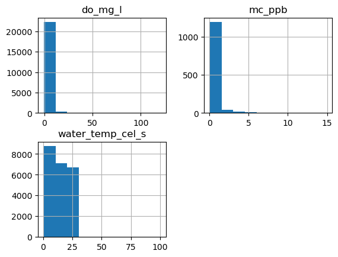

```python
viz = cdf[["do_mg_l", "mc_ppb", "water_temp_cel_s"]]
viz.hist()
plt.show()
```

[figure not shown]

```python
viz = m_df[["chloro_1_fluorosense", "phyco_1_fluorosense", "average_depth_ft", "maximum_depth_ft"]]
viz.hist()
plt.show()
```

## Dissolved Oxygen, Microcystin, and Water Temp are very skewed

```python
cdf['mc_ppb'] = np.log(cdf.mc_ppb) + .0001
```

```python
cdf['do_mg_l'] = np.log(cdf.do_mg_l) + .0001
```

```python
cdf['water_temp_cel_s'] = np.log(cdf.water_temp_cel_s) + .0001
```

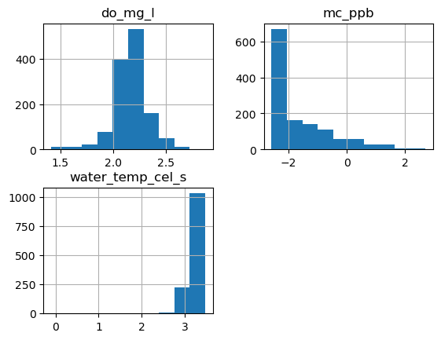

```python
cdf = cdf.dropna()
viz = cdf[["do_mg_l", "mc_ppb", "water_temp_cel_s"]]
viz.hist()
plt.show()
```

## Dissolved Oxygen appears to be more normally distributed, the other two are still fairly skewed

# Phyco Fluorosense, Maximum, and Average depth are also skewed, lets try taking the log

[figure not shown]

```python
viz = m_df[[ "phyco_1_fluorosense", "average_depth_ft", "maximum_depth_ft"]]
viz.hist()
plt.show()
```

# Lets look at relationships between Microcystin and other variables

[figure not shown]

```python
plt.scatter(cdf.do_mg_l, cdf.mc_ppb,  color='blue')
plt.xlabel("Dissolved Oxygen (mg/ L)")
plt.ylabel("Microcystin (Ppb)")
plt.show()
```

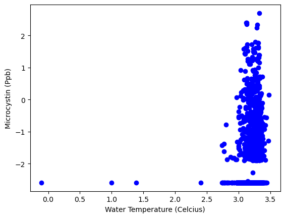

```python
plt.scatter(cdf.water_temp_cel_s, cdf.mc_ppb,  color='blue')
plt.xlabel("Water Temperature (Celcius)")
plt.ylabel("Microcystin (Ppb)")
plt.show()
```

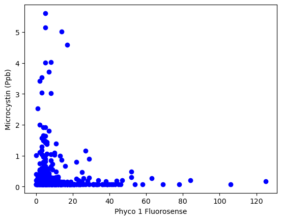

```python
plt.scatter(m_df.phyco_1_fluorosense, m_df.mc_ppb,  color='blue')
plt.xlabel("Phyco 1 Fluorosense")
plt.ylabel("Microcystin (Ppb)")
plt.show()
```

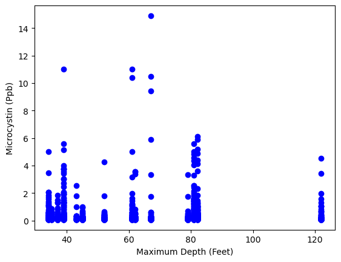

```python
plt.scatter(m_df.maximum_depth_ft, m_df.mc_ppb,  color='blue')
plt.xlabel("Maximum Depth (Feet)")
plt.ylabel("Microcystin (Ppb)")
plt.show()
```

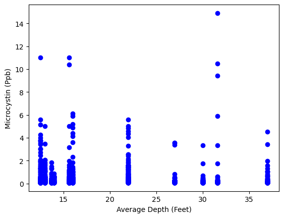

```python
plt.scatter(m_df.average_depth_ft, m_df.mc_ppb,  color='blue')
plt.xlabel("Average Depth (Feet)")
plt.ylabel("Microcystin (Ppb)")
plt.show()
```

### The majority of these variables do not form a useful linear relationship, the best found was microcystin and dissolved oxygen

```python
clean_df_lin = cdf.dropna()
clean_df_lin

msk = np.random.rand(len(clean_df_lin)) < 0.8
train = clean_df_lin[msk]
test = clean_df_lin[~msk]
```

```python
from sklearn import linear_model
regr = linear_model.LinearRegression()
train_x = np.asanyarray(train[['do_mg_l']])
train_y = np.asanyarray(train[['mc_ppb']])
regr.fit(train_x, train_y)
# The coefficients
print ('Coefficients: ', regr.coef_)
print ('Intercept: ',regr.intercept_)
```

```
Coefficients:  [[-0.37276507]]
Intercept:  [-0.91485349]
```

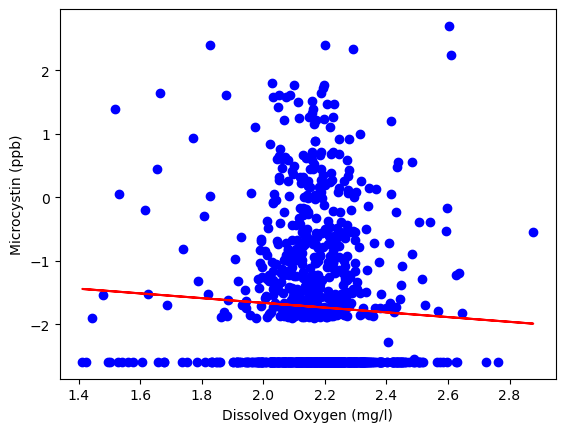

```python
plt.scatter(train.do_mg_l, train.mc_ppb,  color='blue')
plt.plot(train_x, regr.coef_[0][0]*train_x + regr.intercept_[0], '-r')
plt.xlabel("Dissolved Oxygen (mg/l)")
plt.ylabel("Microcystin (ppb)")
```

```python
from sklearn.metrics import r2_score

test_x = np.asanyarray(test[["do_mg_l"]])
test_y = np.asanyarray(test[['mc_ppb']])
test_y_ = regr.predict(test_x)

print("Mean absolute error: %.2f" % np.mean(np.absolute(test_y_ - test_y)))
print("Residual sum of squares (MSE): %.2f" % np.mean((test_y_ - test_y) ** 2))
print("R2-score: %.2f" % r2_score(test_y , test_y_) )
```

```
Mean absolute error: 0.93
Residual sum of squares (MSE): 1.25
R2-score: -0.00
```

# Next we tried some machine learning tricks using more than two variables. The results were not greatly conclusive

```python
import random
import matplotlib.pyplot as plt
from sklearn.cluster import KMeans
from sklearn.datasets import make_blobs
%matplotlib inline

def warn(*args, **kwargs):
    pass
import warnings
warnings.warn = warn
warnings.filterwarnings('ignore')
```

```python
clean_df_k = clean_df[['chloro_1_fluorosense', 'phyco_1_fluorosense', "mc_ppb"]].dropna()
clean_df_k.head()
```

|  | chloro_1_fluorosense | phyco_1_fluorosense | mc_ppb |
| --- | --- | --- | --- |
| 1 | 20 | 10.0 | 0.075 |
| 2 | 21 | 17.0 | 0.075 |
| 3 | 16 | 17.0 | 0.075 |
| 4 | 9 | 5.0 | 0.075 |
| 5 | 10 | 106.0 | 0.075 |

```python
clean_df_k['chloro_1_fluorosense'] = clean_df_k['chloro_1_fluorosense'].astype(float)
```

```python
from sklearn.preprocessing import StandardScaler
X = clean_df_k.values[:,1:]
X = np.nan_to_num(X)
Clus_dataSet = StandardScaler().fit_transform(X)
Clus_dataSet
```

```
array([[-0.0551595 , -0.35195135],
       [ 0.49526193, -0.35195135],
       [ 0.49526193, -0.35195135],
       ...,
       [-0.36968604, -0.35195135],
       [ 0.02347213, -0.35195135],
       [-0.36968604, -0.35195135]])
```

```python
clusterNum = 4
k_means = KMeans(init = "k-means++", n_clusters = clusterNum, n_init = 12)
k_means.fit(X)
labels = k_means.labels_
print(labels)
```

```
[0 2 2 0 1 3 2 2 0 2 1 3 0 2 3 3 2 2 3 2 2 0 0 0 2 0 2 0 3 2 2 2 2 2 2 0 0
 0 0 2 0 0 0 0 0 0 0 0 0 0 0 0 0 0 0 0 0 0 0 0 0 0 0 0 0 0 0 0 0 0 0 0 0 0
 0 0 0 0 0 0 0 2 0 0 0 0 0 0 0 0 0 0 0 0 0 0 0 2 0 0 2 0 2 0 2 0 2 0 2 2 2
 2 0 2 0 0 0 0 0 0 0 0 0 0 0 0 0 0 0 0 0 0 0 0 0 0 2 3 3 2 2 2 3 3 3 3 2 3
 2 3 2 3 3 2 3 3 0 0 0 0 0 0 0 0 0 0 0 0 0 0 0 0 0 0 0 0 0 0 0 0 0 0 0 2 2
 0 0 2 0 0 0 0 0 0 0 0 0 0 2 0 0 0 0 2 0 0 2 0 0 0 0 2 2 0 0 2 2 2 0 0 0 0
 0 0 0 2 2 2 2 0 2 0 2 2 2 2 2 2 3 1 3 2 0 2 2 2 0 2 0 0 0 0 3 2 0 1 3 2 2
 2 2 3 2 2 2 1 0 0 0 0 0 0 0 0 0 0 0 0 0 0 0 0 0 0 0 0 0 0 0 0 0 0 0 0 2 0
 0 0 0 0 0 0 0 0 0 0 0 0 0 0 0 0 0 0 0 0 0 0 0 0 0 0 0 0 0 0 0 0 0 0 0 0 0
 0 0 0 0 0 0 0 0 0 0 0 0 0 0 0 0 0 0 0 0 0 0 0 0 0 0 0 0 0 0 0 0 2 0 0 0 0
 0 0 0 0 0 0 0 0 0 0 0 0 0 0 0 0 0 0 0 0 0 0 0 0 0 2 0 0 0 2 0 0 2 0 0 0 0
 0 0 2 2 0 0 0 0 0 0 3 0 2 0 3 0 0 0 0 0 0 0 0 0 0 0 0 3 0 0 0 0 2 2 0 0 0
 0 0 0 0 0 0 0 0 0 0 0 0 0 0 0 0 0 2 0 0 0 0 3 3 0 0 0 0 0 0 0 0 0 0 0 0 0
 2 0 3 0 0 2 2 0 0 2 0 2 0 2 3 0 2 0 2 0 0 0 2 0 2 2 2 0 2 2 2 2 3 3 0 2 2
 3 2 0 2 2 2 2 3 2 0 0 0 0 0 0 0 0 0]
```

```python
clean_df_k["Clus_km"] = labels
clean_df_k.head(5)
```

|  | chloro_1_fluorosense | phyco_1_fluorosense | mc_ppb | Clus_km |
| --- | --- | --- | --- | --- |
| 1 | 20.0 | 10.0 | 0.075 | 0 |
| 2 | 21.0 | 17.0 | 0.075 | 2 |
| 3 | 16.0 | 17.0 | 0.075 | 2 |
| 4 | 9.0 | 5.0 | 0.075 | 0 |
| 5 | 10.0 | 106.0 | 0.075 | 1 |

```python
clean_df_k.groupby('Clus_km').mean()
```

| Clus_km | chloro_1_fluorosense | phyco_1_fluorosense | mc_ppb |
| --- | --- | --- | --- |
| 0 | 6.629820 | 5.336761 | 0.342675 |
| 1 | 15.200000 | 92.400000 | 0.120400 |
| 2 | 16.833333 | 17.212963 | 0.222463 |
| 3 | 27.941176 | 39.382353 | 0.144000 |

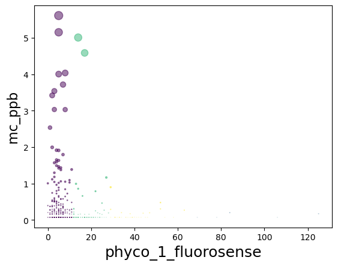

```python
area = np.pi * ( X[:, 1])**2
plt.scatter(X[:, 0], X[:, 1], s=area, c=labels.astype(np.float), alpha=0.5)
plt.xlabel('phyco_1_fluorosense', fontsize=18)
plt.ylabel('mc_ppb', fontsize=16)

plt.show()
```

## Does not prove to be very helpful

### Taking the log of our data, provided different, but interesting results while adding maximum and average depth

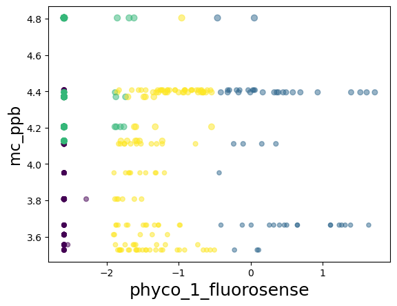

```python
area = np.pi * ( X[:, 1])**2
plt.scatter(X[:, 0], X[:, 2], s=area, c=labels.astype(np.float), alpha=0.5)
plt.xlabel('phyco_1_fluorosense', fontsize=18)
plt.ylabel('mc_ppb', fontsize=16)

plt.show()
```

## Some intersting grouping, but all over the place

## Dendrogram for the year of 2018

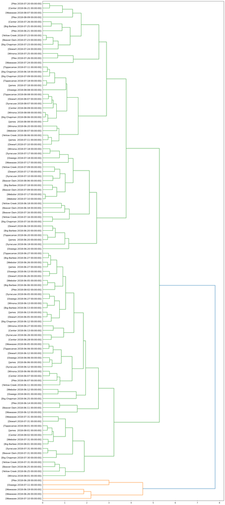

```python
fig = pylab.figure(figsize=(18,50))
def llf(id):
    return '[%s %s]' % (filtered_pdf['lake_name'][id], (filtered_pdf['date'][id]))

dendro = hierarchy.dendrogram(Z, leaf_label_func=llf, leaf_rotation=0, leaf_font_size =12, orientation = 'right')
```

# Clustering using SciKit and data from 2018

[output not shown]

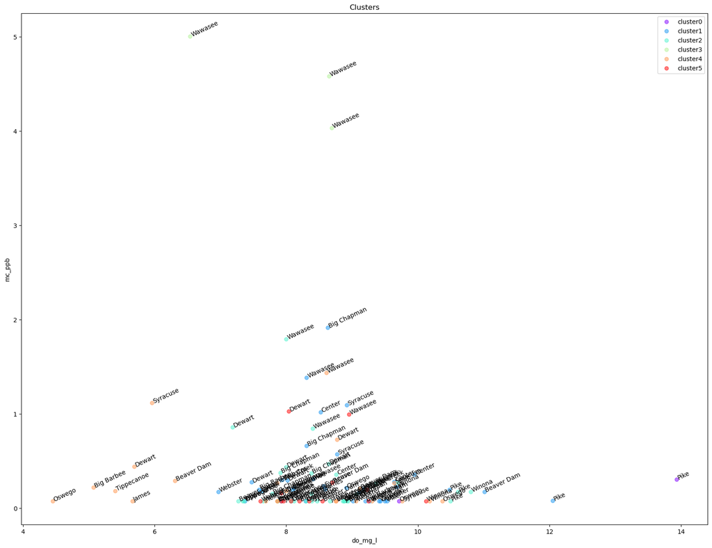

```python
import matplotlib.cm as cm
n_clusters = max(agglom.labels_)+1
colors = cm.rainbow(np.linspace(0, 1, n_clusters))
cluster_labels = list(range(0, n_clusters))

# Create a figure of size 6 inches by 4 inches.
plt.figure(figsize=(20,15))

for color, label in zip(colors, cluster_labels):
    subset = filtered_pdf[filtered_pdf.cluster_ == label]
    for i in subset.index:
            plt.text(subset.do_mg_l[i], subset.mc_ppb[i],str(subset['lake_name'][i]), rotation=25)
    plt.scatter(subset.do_mg_l, subset.mc_ppb, c=color, label='cluster'+str(label),alpha=0.5)
#    plt.scatter(subset.horsepow, subset.mpg)
plt.legend()
plt.title('Clusters')
plt.xlabel('do_mg_l')
plt.ylabel('mc_ppb')
```

## Scikit with Cloro and Phyco in 2018

[output not shown]

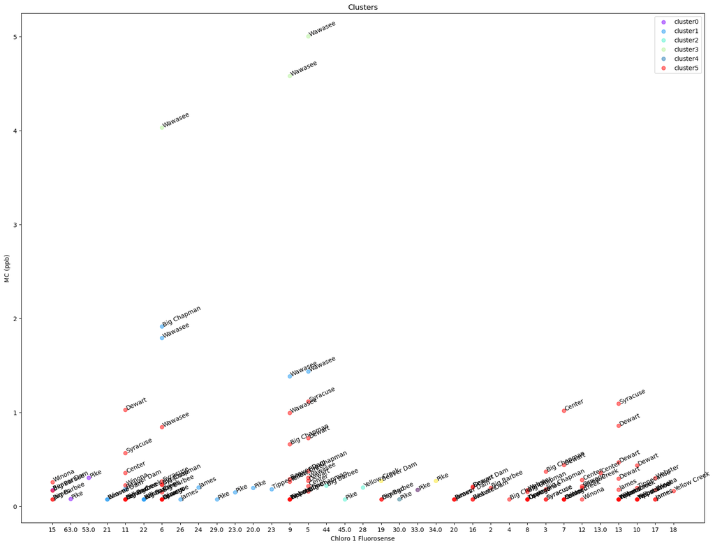

```python
import matplotlib.cm as cm
n_clusters = max(agglom.labels_)+1
colors = cm.rainbow(np.linspace(0, 1, n_clusters))
cluster_labels = list(range(0, n_clusters))

# Create a figure of size 6 inches by 4 inches.
plt.figure(figsize=(20,15))

for color, label in zip(colors, cluster_labels):
    subset = filtered_pdf[filtered_pdf.cluster_ == label]
    for i in subset.index:
            plt.text(subset.chloro_1_fluorosense[i], subset.mc_ppb[i],str(subset['lake_name'][i]), rotation=25)
    plt.scatter(subset.chloro_1_fluorosense, subset.mc_ppb, c=color, label='cluster'+str(label),alpha=0.5)
#    plt.scatter(subset.horsepow, subset.mpg)
plt.legend()
plt.title('Clusters')
plt.xlabel('Chloro 1 Fluorosense')
plt.ylabel('MC (ppb)')
```